# Exploring Data Songs in Spotify

Final Project Report  
Data Science 1 with R (STAT 301-1)

Author

Jessie Chen

Published

December 6, 2023

**Github Repo Link**

[My Repo Link](https://github.com/stat301-1-2023-fall/final-project-1-Jchench)

## Introduction

I’m interested in looking at data on music to determine what musical elements make songs more popular and how these elements have changed over time. For this project, I gathered data from the music streaming-platform Spotify to look at some of the most popular songs among users and particular elements that might have made those songs popular. Some of the initial research questions I have are: What are the musical elements that make a song popular among listeners? Are there trends and patterns in musical elements and song popularity that have changed over time?

The `spotify_data_top` dataset I am using collected Spotify-made playlists that include between 50-130 tracks of the most popular songs each year from 1990-2022. There is information on each song’s artist, album release date, genre, and other characteristics (i.e. BPM, key, and time signature). [This data was taken from Kaggle, courtesy of user KRISTOFFER.](https://www.kaggle.com/datasets/ztofff/top-1990-2022) The `spotify_streams` dataset I am using collected data on 10000 Spotify songs and information on their number of streams. [This data was taken from Kaggle, courtesy of user RAKKESH ARAVIND G.](https://www.kaggle.com/datasets/rakkesharv/spotify-top-10000-streamed-songs)

## Data overview & quality

`spotify_data_top` has 2610 observations and 26 variables. There are 12 categorical, 12 numeric, and 2 date and time-related variables. `spotify_streams` has 11084 rows and 9 variables. There are 3 categorical and 6 numeric variables.

In terms of potential issues, both the datasets doesn’t seem to have too many variables with a large number of missing values. However, many `genre` values seem to be missing though, which is something to keep in mind. The biggest issue that I ran into when trying to join the two datasets was in regards to the keys that I decided to join by. I wanted to join the two data sets by artist and song names, however, this became hard to do because the datasets seemed to have multiple versions of the same songs by the same artists. I was able to overcome this issue by filtering for distinct values and summing the total number of streams. In my data cleaning, I also did a couple of variable conversions so that the dataset would be easier to work with.

## Explorations

**Addressing the first research question I proposed: What are the musical elements that make a song popular among listeners?**

I decided to define “popularity” of songs based on how many total streams a song garnered on Spotify. Here is the distribution for this variable:

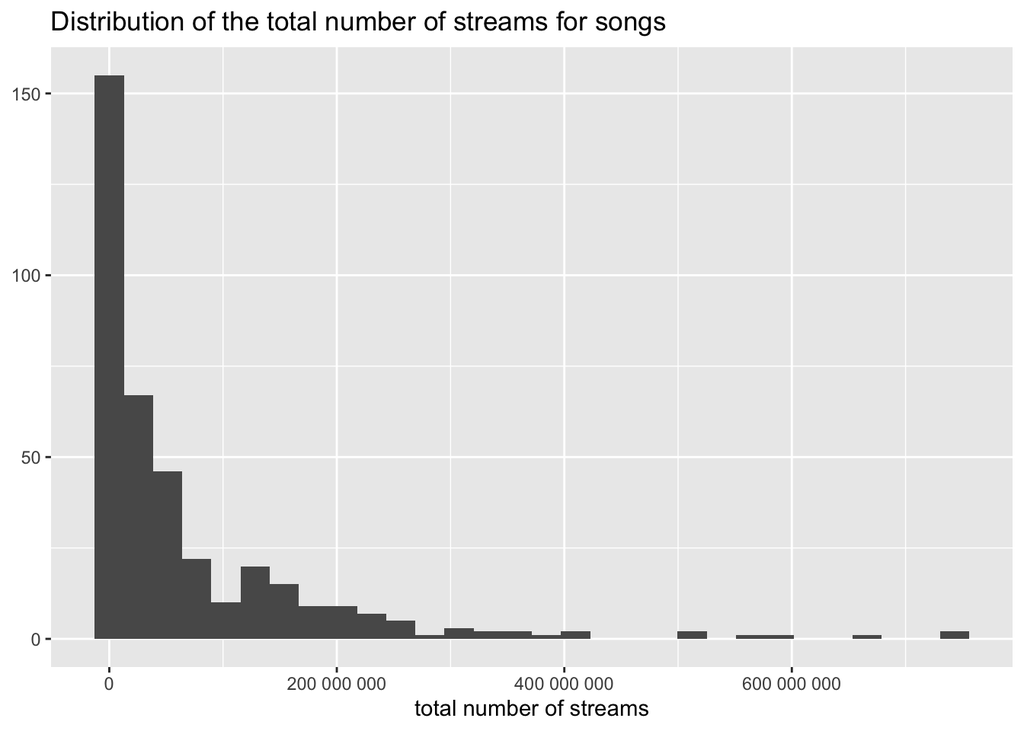

As we can see here, the distribution of the total number of streams is unimodal and significantly skewed to the right, meaning that most of the songs in this dataset have less than 100 million total streams. There seem to be a lot of outliers after 400 million total streams so we may want to just ignore these values for the next couple of explorations.

**Looking at the most important numeric variable:**

To begin with I looked at the correlation coefficient between all the numeric variables and the total number of streams:

Numeric Variables Correlated with Total Number of Streams

| Variables | Correlation Coefficient |
| --- | --- |
| final_streams | 1.00 |
| year | 0.31 |
| dance | 0.15 |
| loud | 0.12 |
| live | 0.06 |
| speech | 0.03 |
| instrumental | 0.02 |
| acoustic | 0.00 |
| bpm | -0.01 |
| energy | -0.03 |
| song_seconds | -0.08 |
| happy | -0.09 |

Other than the obvious variable of `final_stream` (the total number of streams) and the non-musical element-related variable of `year`, this shows that the “danceability” of a song (represented in percentage) is the most correlated with total stream numbers (correlation coefficient of 0.15).

Thus, I decide to looks more closely at this variable through a univariate analysis:

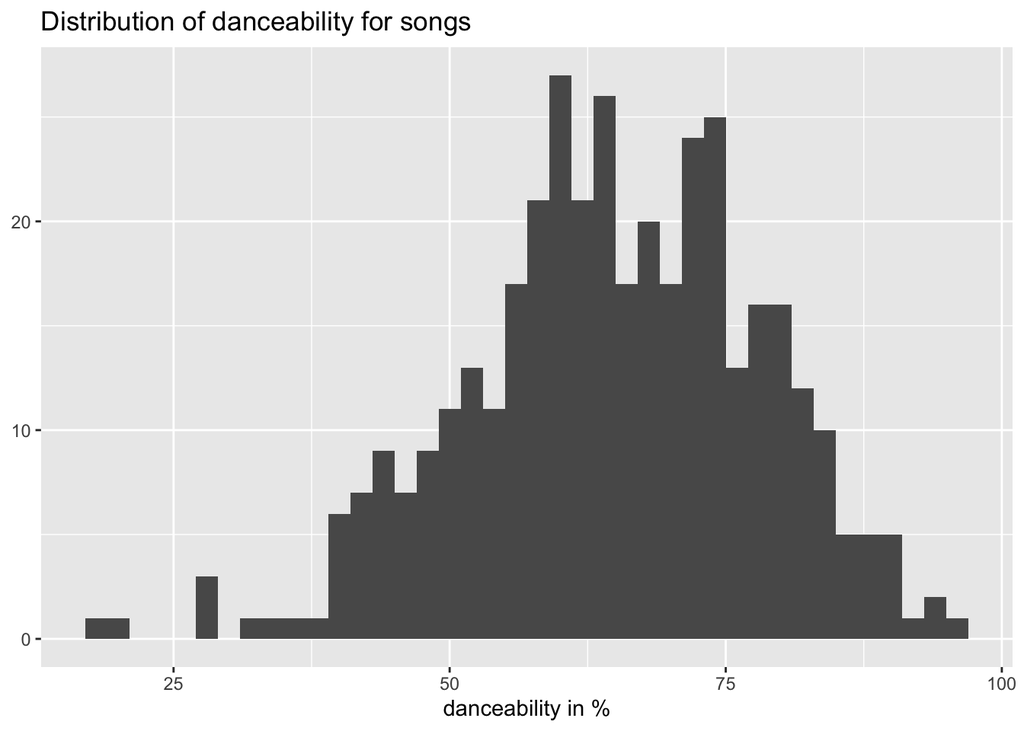

We can see that the distribution of danceability seems to have more or less a unimodal normal distribution. There might be a couple of song outliers below the 25% mark for danceability, so I may ignore them for explorations going forward.

Next, I decided to look at a bivariate analysis for a song’s danceability and the total number of streams:

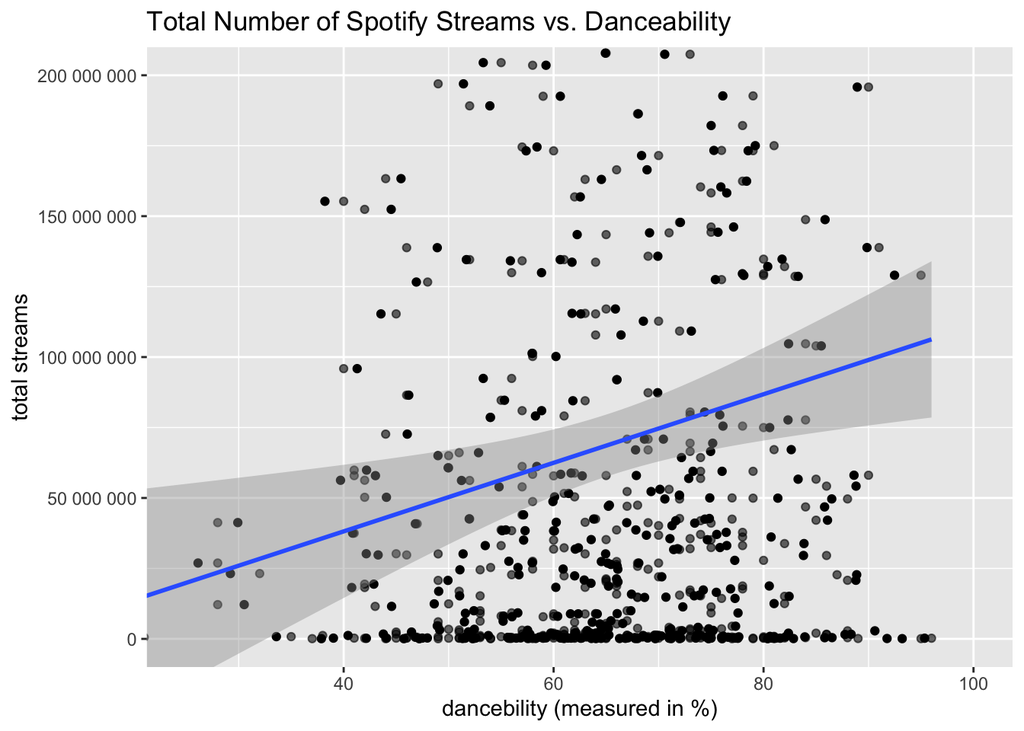

We can see here that there is a relatively weak positive correlation between the total number of Spotify streams for a song and its danceability. Nonetheless, this means that songs that are more “danceable” tend to be played somewhat more often by Spotify users, and thus are more popular.

Lastly, I looked at a multivariate analysis of danceability, the total number of streams, and genre:

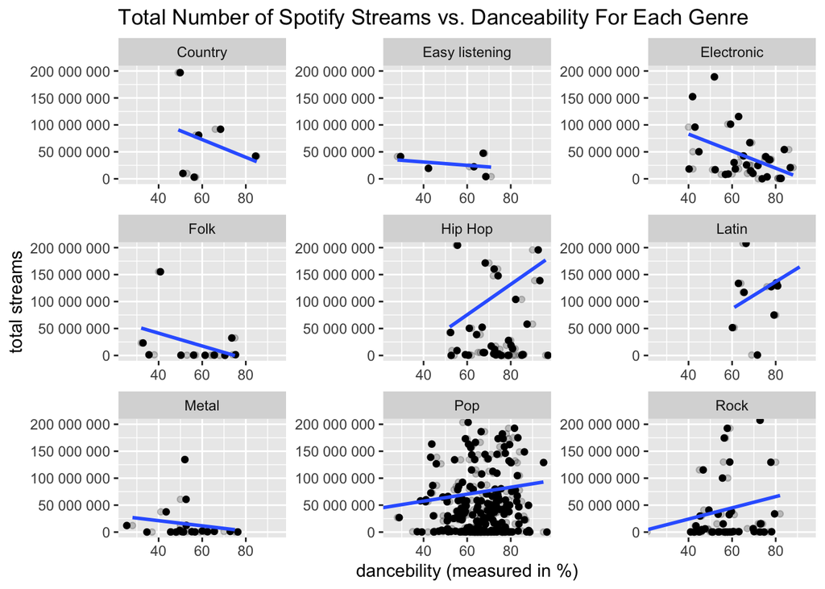

The relationship between danceability and total number of streams changes when we look at different genres. For Metal, country, folk, easy listening, and electronic, the relationship is negative, whereas for all the other genres, the relationship is positive. This means that listeners have different preferences for how “danceable” a song is depending on what genre they are listening to.

**Looking at the most important categorical variable:**

An important categorical variable I decided to explore when considering this research question was key signature. In particular, I decided to only focus on differentiating between major and minor keys to see if either feature would correlate with more streams. I did a bivariate analysis between a song’s key signature and total number of streams to see if there are any noticeable patterns:

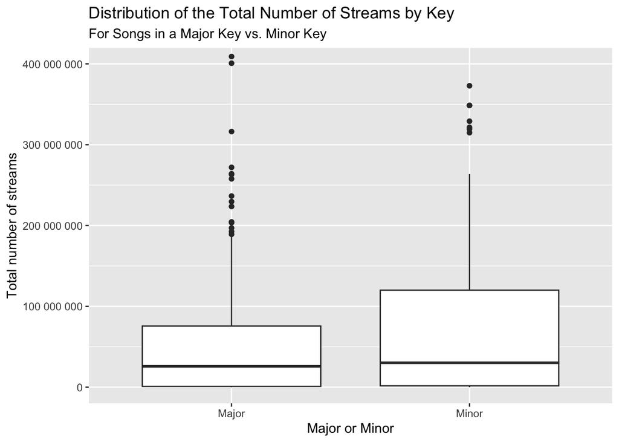

Then, I did a multivariate analysis for the major/ minor key signature, total number of streams, and genres:

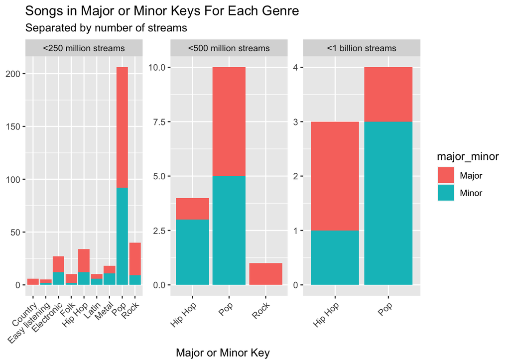

**Addressing the second research question I proposed: Are there trends and patterns in musical elements and song popularity that have changed over time?**

I decided to first look at the distribution of years for when songs are released:

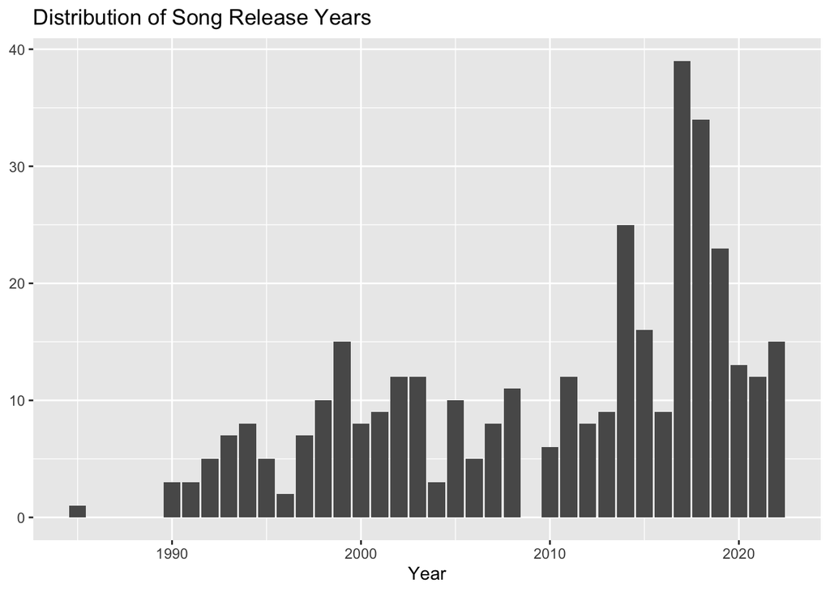

**Looking at the most important numeric variable:**

To begin with I looked at the correlation coefficient between all the numeric variables and the song release year:

Numeric Variables Correlated with Year

| Variables | Correlation Coefficient |
| --- | --- |
| song_seconds | -0.43 |
| instrumental | -0.13 |
| happy | -0.07 |
| acoustic | -0.05 |
| energy | -0.05 |
| bpm | 0.06 |
| speech | 0.11 |
| live | 0.12 |
| dance | 0.18 |
| final_streams | 0.31 |
| loud | 0.33 |
| year | 1.00 |

We can see from the table that song duration (measure in seconds) is most closely correlated with the year in which a song is released (correlation coefficient of -0.43).

Thus, I decided to conduct a bivariate analysis between song duration and year:

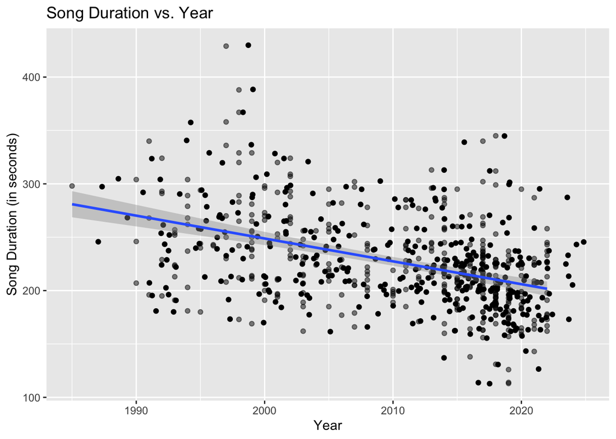

The bivariate analysis supports the moderately strong, negative correlation between year and song duration. This shows that most songs, in general, have been getting shorter and shorter in length each year.

Next, let’s look at a multivariate analysis between year, song duration, and total number of streams:

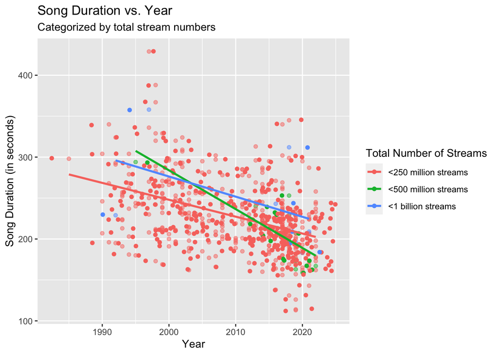

As we can see here, songs duration seems to have decreased over the years for all total stream numbers. This means that songs, in general, regardless of popularity, have been getting shorter and shorter.

**Looking at the most important categorical variable:**

An important categorical variable I decided to explore when considering this research question is genre.

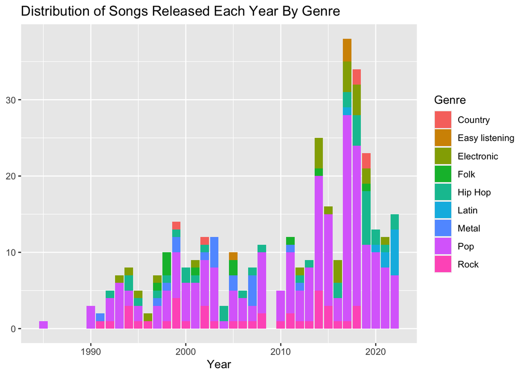

As we can see from the bar graph, pop songs seem to constitute a significant portion of the songs released each year. Notably, rock songs used to be released more often in the 90s - late 2010s, but seem to have become less common in the 2020s. Lastly, more songs in the Latin genre have been released in recent years.

Next, let’s look at a multivariate analysis between genre, year, and total number of streams:

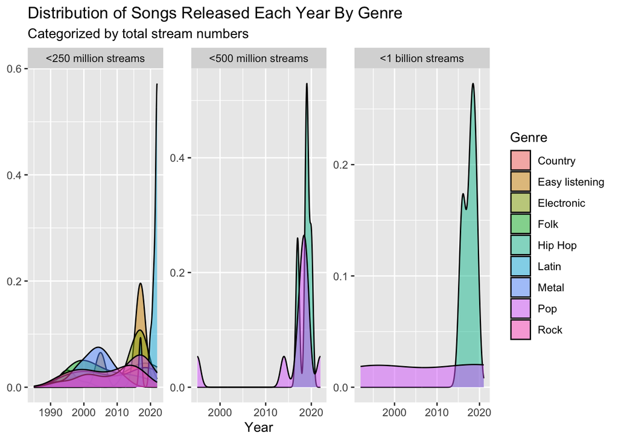

## Conclusion:

Here are song of the main insights and conclusions that I have generated for my research questions based on my exploratory data analysis:

**What are the musical elements that make a song popular among listeners?**

**Are there trends and patterns in musical elements and song popularity that have changed over time?**

I found that song duration (in seconds) has seemed to decreased over the years, and this is mostly true for songs of any number of total streams. I kind of expected this finding because do feel like media content in general has gotten shorter and shorter recently due to development in social media and other technologies. I was a little bit more surprised when looking at the genres of song releases each year as I didn’t really expect the number of songs in the Latin category to have increased in these past few years. I did expect hip hop and pop music genres to constitute most of the song releases, since I did notice that a large number of the songs in this dataset fall under these categories.

## References:

**Data from:**

G, Rakkesh Aravind. “Spotify Top 10000 Streamed Songs.” Kaggle, 2 Jan. 2023, www.kaggle.com/datasets/rakkesharv/spotify-top-10000-streamed-songs.

Kristoffer. “Spotify Top Tracks 1990-2022.” Kaggle, 27 Aug. 2023, www.kaggle.com/datasets/ztofff/top-1990-2022.